# 05_xtt_assay

## XTT Assay

by Anastasia Abashidze

Blavatnik Center for Drug Discovery

## Introduction

#### XTT Assay

Cell proliferation assays are widely used in cell biology for the study of growth factors, cytokines and media components, and for the screening of cytotoxic agents and for lymphocyte activation. In XTT assay we quantify cell viability using tetrazolium salt XTT. This method is based on the fact that live cells reduce tetrazolium salts into colored formazan compounds. The biochemical procedure is based on the activity of mitochondria enzymes which are inactivated shortly after cell death. XTT is a colorimetric assay, so we measure absorbance.

###### XTT calculation

[figure not shown]

#### Assay Data

In this experiment we use HEK293 cells to measure toxicity of nine different compounds. Blank wells refer to the absorbance of medium without cells, and each compound has its own blank wells, since some compounds can interfere with absorbance measures. Compound blanks are listed in the 'Status' field in the layout file. CONTROL wells refer to the absorbance of medium with cells, and DMSO is the absorbance of cells with DMSO. We will subtract blanks of compounds from 'raw' absorbance values of compounds and save the result in 'abs_norm' column.

## The Workflow

### Import Packages and create Output Folder

```python
from nbdev.showdoc import *
import os
import sys
sys.path.append('..//')
import pandas as pd
import numpy as np
from scipy import stats
import matplotlib as mpl
%matplotlib inline
import matplotlib.colors as colors
import matplotlib.pyplot as plt
import seaborn as sns
sns.set(context = 'notebook', style = 'white', palette = 'dark')
from IPython.display import Image
import simplydrug as sd
```

#### Create folder to save the output

```python
path = ('xtt_output')
if not os.path.exists(path):
    os.mkdir(path)
    print('Output folder created')
```

#### Defining parameters

```python
# path to data
data_path = 'test_data//xtt_data.xlsx'

# path to layout
layout_path = 'test_data//xtt_layout.xlsx'
```

### Load Data and add Layout

```python
data = pd.DataFrame(np.asarray(pd.ExcelFile(data_path).parse(0)).reshape(-1), columns = ['raw'])
layout = pd.DataFrame()
for sheet in pd.ExcelFile(layout_path).sheet_names:   # create columns from excel file
    layout[sheet] = np.asarray(pd.ExcelFile(layout_path).parse(sheet)).reshape(-1)
    print('added ', sheet)

data = pd.concat([data, layout], axis = 1, sort = False)
print(data.shape)
display(data[100:105])
```

```
added  Well
added  Compound_id
added  Dose
added  Status
(384, 5)
```

|  | raw | Well | Compound_id | Dose | Status |
| --- | --- | --- | --- | --- | --- |
| 100 | 1.2530 | E5 | Compound1 | 15.0 | Sample |
| 101 | 1.2460 | E6 | Compound1 | 20.0 | Sample |
| 102 | 1.5898 | E7 | Compound1 | 25.0 | Sample |
| 103 | 1.4852 | E8 | Compound1 | 30.0 | Sample |
| 104 | 1.7363 | E9 | Compound1 | 35.0 | Sample |

### Subtract Blanks

```python
print(data.Status.unique())
```

```
['Reference' 'Compound9_BL' 'Sample' 'BL' 'DMSO' 'CONTROL' 'Compound1_BL'
 'Compound5_BL' 'Compound2_BL' 'Compound6_BL' nan 'Compound3_BL'
 'Compound7_BL' 'Compound4_BL' 'Compound8_BL']
```

#### Subtract compound blanks means

```python
results = pd.DataFrame()
for name, group in data.groupby('Compound_id'):
    group = group.copy()
    group_blank_mean = data[data.Status == name + '_BL'].raw.mean()
    print(f'Compound: {name} blank mean: {str(group_blank_mean)}')
    group['abs_norm'] = group.raw - group_blank_mean
    results = results.append(group, sort = False)
display(results.head(3))
```

```
Compound: Compound1 blank mean: 0.535385
Compound: Compound2 blank mean: 0.385215
Compound: Compound3 blank mean: 0.36633499999999997
Compound: Compound4 blank mean: 0.38382000000000005
Compound: Compound5 blank mean: 0.497845
Compound: Compound6 blank mean: 0.37415
Compound: Compound7 blank mean: 0.374255
Compound: Compound8 blank mean: 0.38401
Compound: Compound9 blank mean: 0.39063000000000003
```

|  | raw | Well | Compound_id | Dose | Status | abs_norm |
| --- | --- | --- | --- | --- | --- | --- |
| 50 | 1.5865 | C3 | Compound1 | 5.0 | Sample | 1.051115 |
| 51 | 1.5712 | C4 | Compound1 | 10.0 | Sample | 1.035815 |
| 52 | 1.6372 | C5 | Compound1 | 15.0 | Sample | 1.101815 |

#### Heatmap for normalized absorbance

```python
sd.heatmap_plate(df = results, layout_path = layout_path, features = ['abs_norm'], path = path, save_as = '_heatmap_mp.png')
```

```
INFO:root:heatmap_plate: abs_norm_heatmap_mp.png saved to the output folder
```

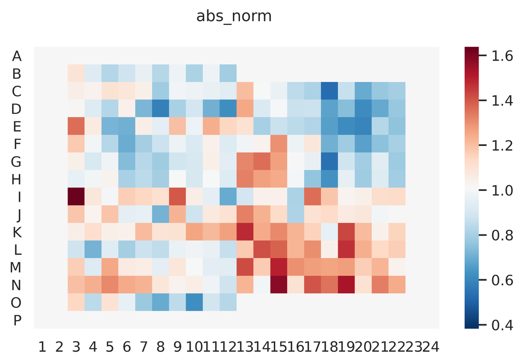

```python
Image(filename = path +'//abs_norm_heatmap_mp.png',  width = 400)
```

### Calculate Survival

```python
blank_mean = data[data.Status == 'BL'].raw.mean()
control_mean = data[data.Status == 'CONTROL'].raw.mean()

print('Control mean : ', control_mean)
print('Blank mean: ',  blank_mean)

survival = lambda x, y: x*100/y  # survival helper function
results['Response'] = survival(results.abs_norm, (control_mean - blank_mean))
results = results.dropna().sort_values(by = ['Compound_id', 'Dose'], ascending = False) # IMPORTANT to remove controls!
display(results.head())
```

```
Control mean :  1.60425
Blank mean:  0.3679928571428571
```

|  | raw | Well | Compound_id | Dose | Status | abs_norm | Response |
| --- | --- | --- | --- | --- | --- | --- | --- |
| 35 | 1.1807 | B12 | Compound9 | 50.0 | Sample | 0.79007 | 63.908225 |
| 347 | 1.2216 | O12 | Compound9 | 50.0 | Sample | 0.83097 | 67.216598 |
| 34 | 1.3644 | B11 | Compound9 | 45.0 | Sample | 0.97377 | 78.767593 |
| 346 | 1.2815 | O11 | Compound9 | 45.0 | Sample | 0.89087 | 72.061869 |
| 33 | 1.2047 | B10 | Compound9 | 40.0 | Sample | 0.81407 | 65.849569 |

### Fitting Dose-Response for Survival Rates

```python
fitTable = sd.run_dr(df = results, y_label = '%_survival', path = path, save_as = '_xtt.png')
fitTable.to_csv(path + '//xtt_fittable.csv', index = False)
```

```
INFO:root:fitting Compound1
INFO:root:run_dr: dr_Compound1_xtt.png saved to the output folder
INFO:root:fitting Compound2
INFO:root:run_dr: dr_Compound2_xtt.png saved to the output folder
INFO:root:fitting Compound3
INFO:root:run_dr: dr_Compound3_xtt.png saved to the output folder
INFO:root:fitting Compound4
INFO:root:run_dr: dr_Compound4_xtt.png saved to the output folder
INFO:root:fitting Compound5
INFO:root:run_dr: dr_Compound5_xtt.png saved to the output folder
INFO:root:fitting Compound6
INFO:root:run_dr: dr_Compound6_xtt.png saved to the output folder
INFO:root:fitting Compound7
INFO:root:run_dr: dr_Compound7_xtt.png saved to the output folder
INFO:root:fitting Compound8
INFO:root:Fitting curve failed: Optimal parameters not found: Number of calls to function has reached maxfev = 1000.
INFO:root:fitting Compound9
INFO:root:Fitting curve failed: Optimal parameters not found: Number of calls to function has reached maxfev = 1000.
```

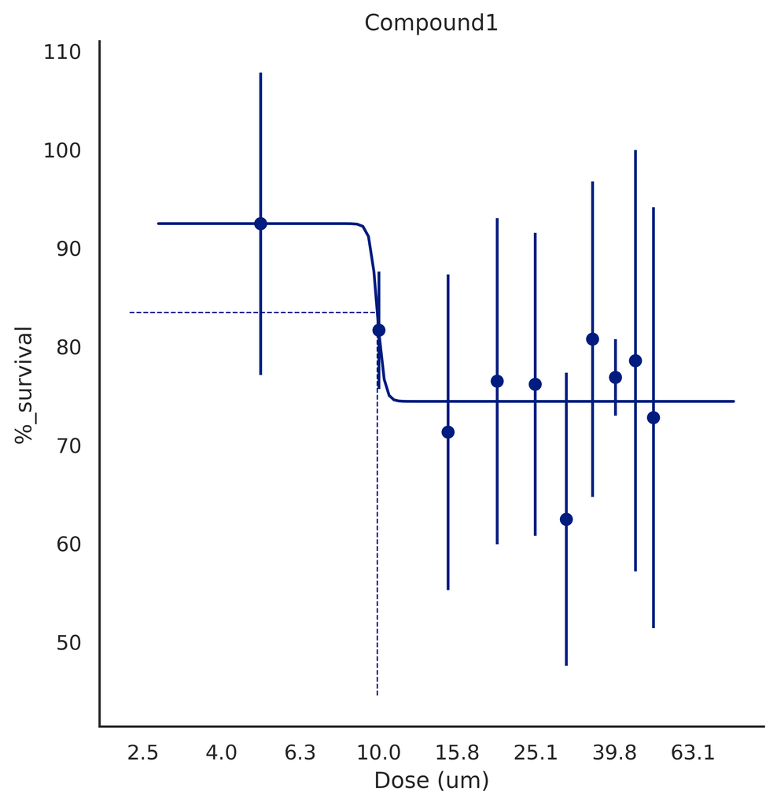

```python
Image(filename = path +'//dr_Compound1_xtt.png',  width = 300)
```

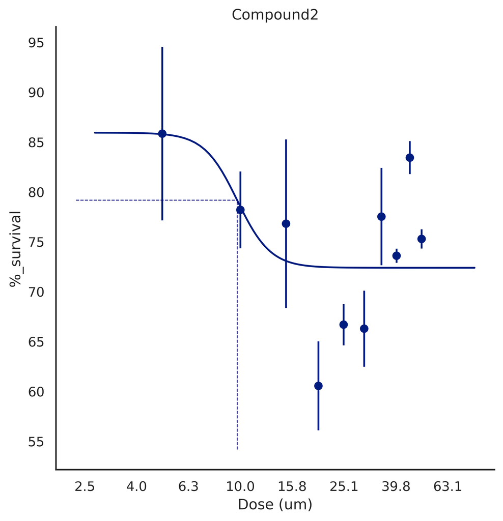

```python
Image(filename = path +'//dr_Compound2_xtt.png',  width = 300)
```

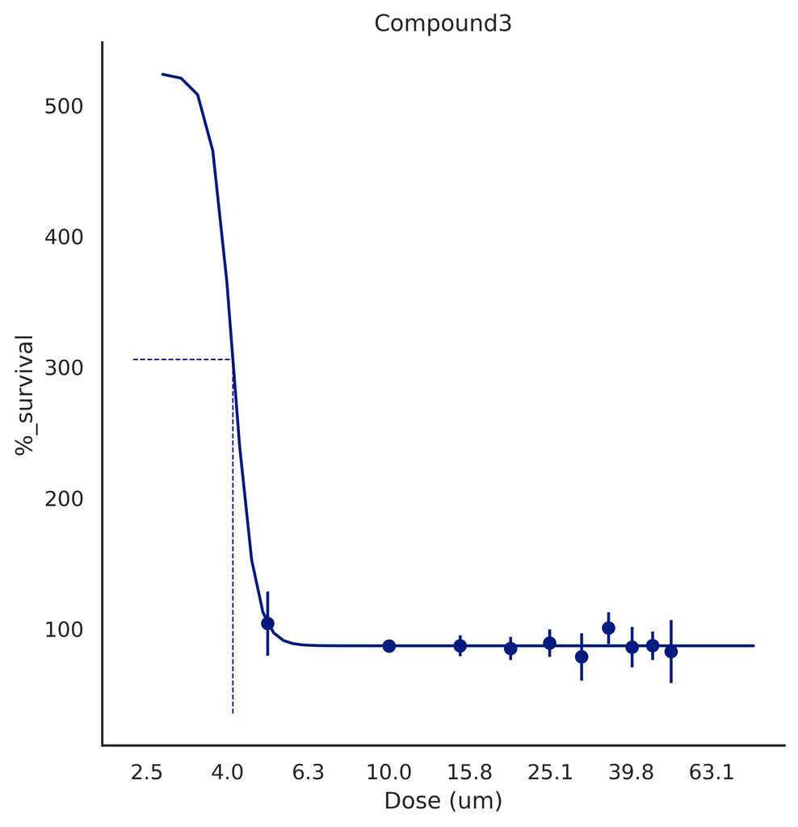

```python
Image(filename = path +'//dr_Compound3_xtt.png',  width = 300)
```

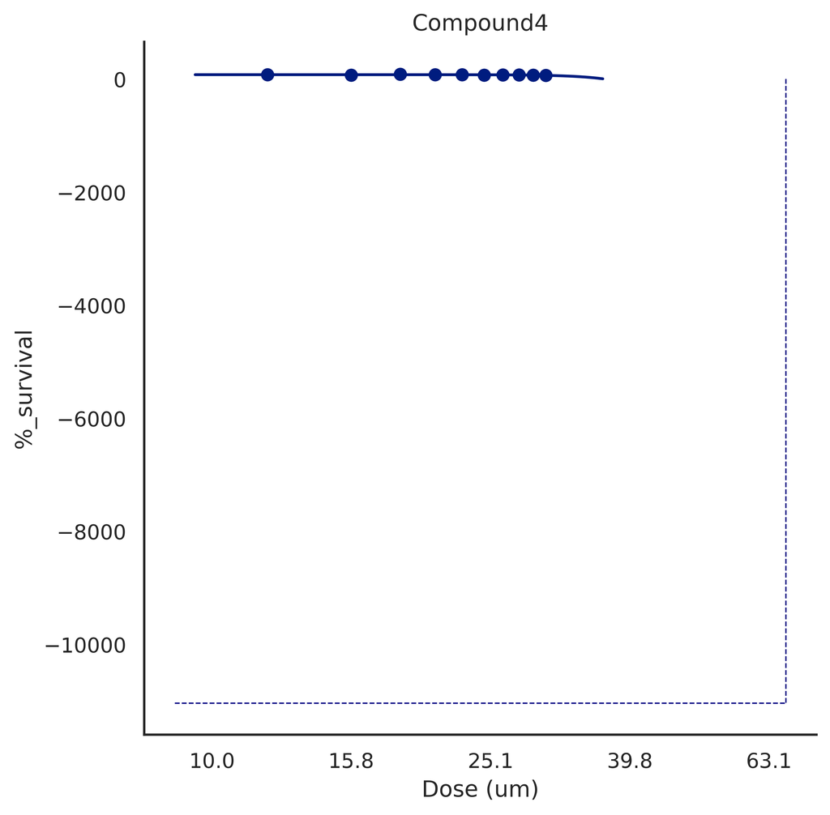

```python
Image(filename = path +'//dr_Compound4_xtt.png',  width = 300)
```

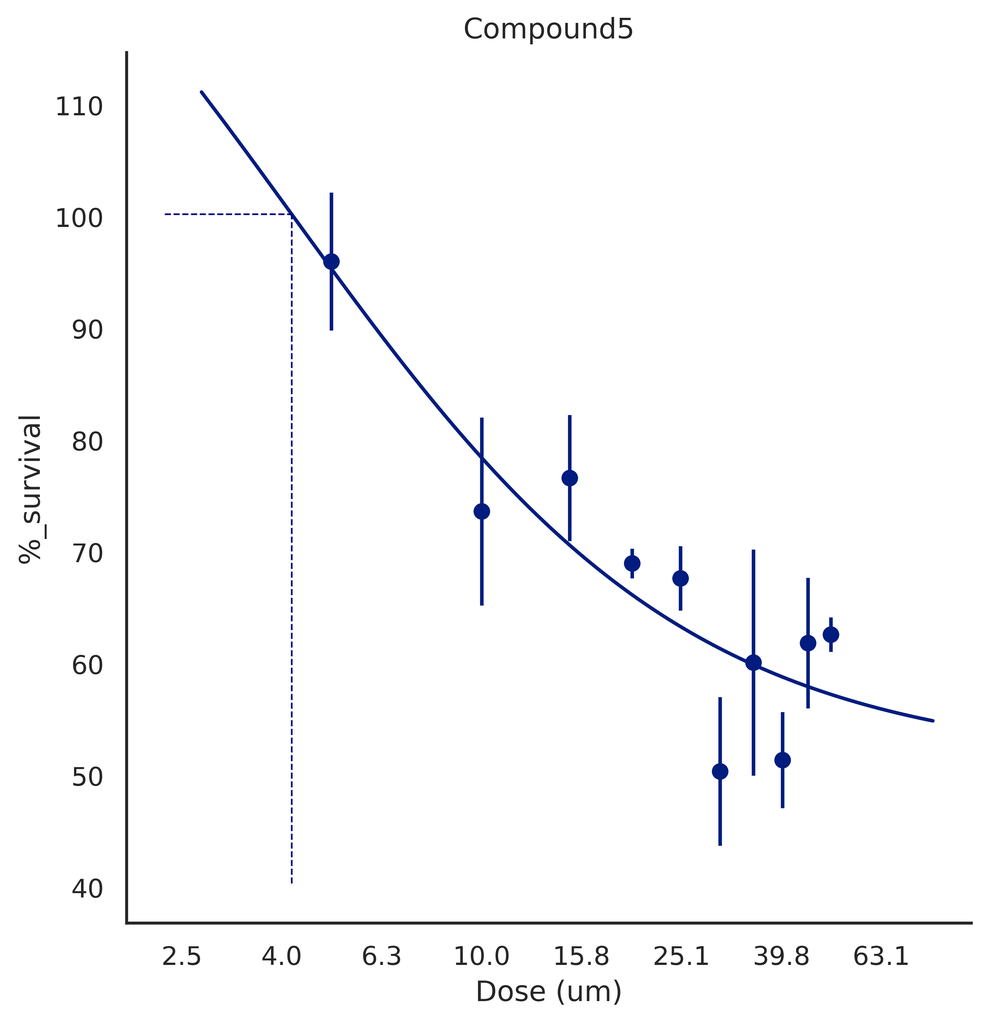

```python
Image(filename = path +'//dr_Compound5_xtt.png',  width = 300)
```

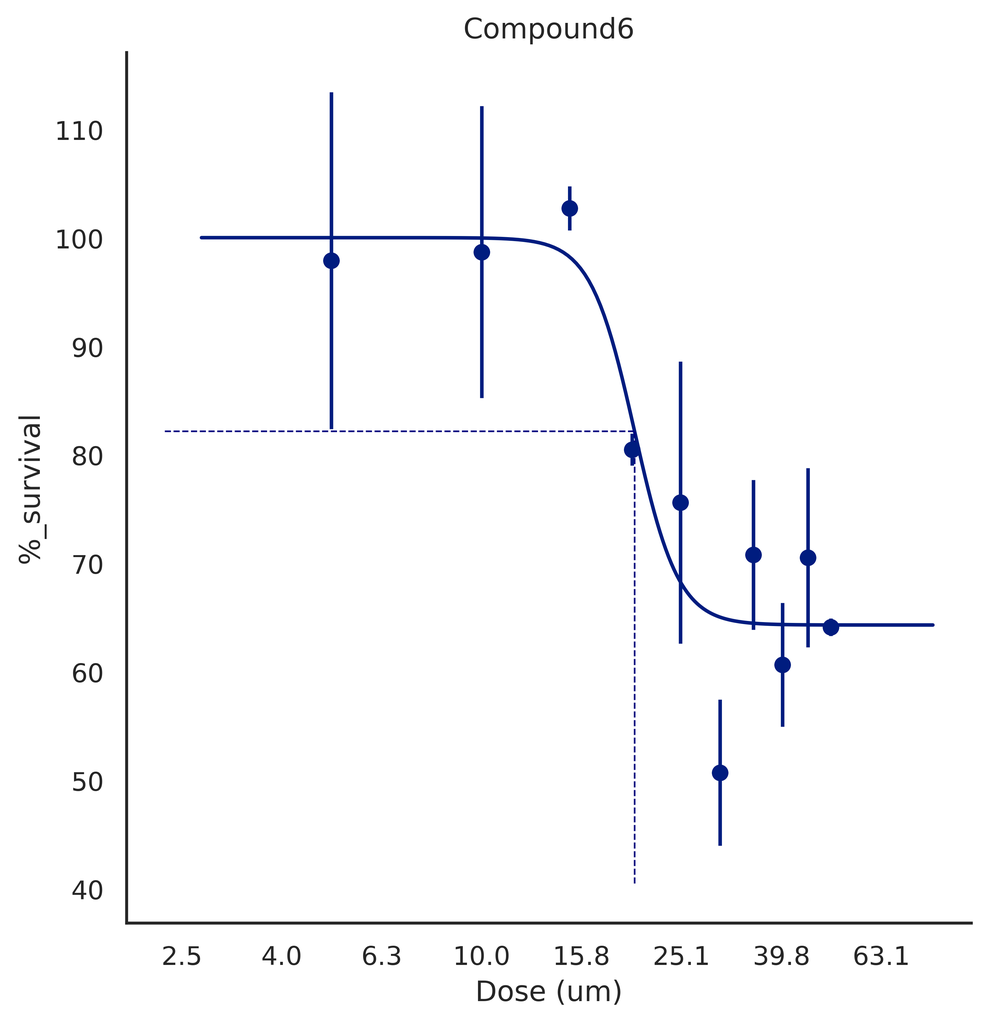

```python
Image(filename = path +'//dr_Compound6_xtt.png',  width = 300)
```

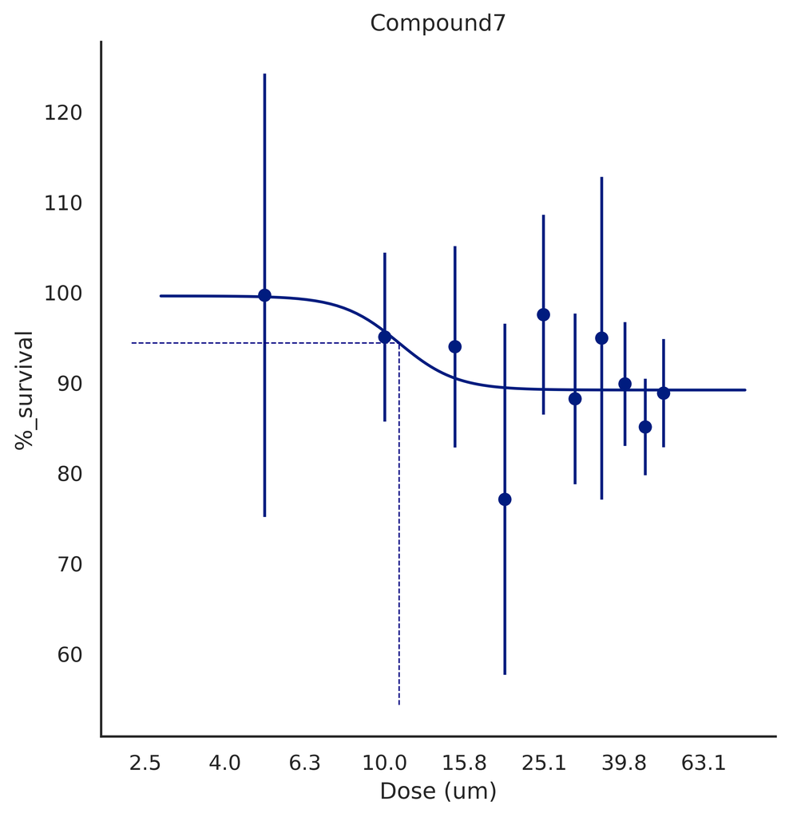

```python
Image(filename = path +'//dr_Compound7_xtt.png',  width = 300)
```

#### Save fitTable to csv

```python
display(fitTable)
fitTable.to_csv(path +'//' + 'xtt_fittable.csv')
```

|  | Compound_id | N | hill slope | min response | max response | EC50 | r_squared | residuals |
| --- | --- | --- | --- | --- | --- | --- | --- | --- |
| 0 | Compound1 | 10 | 48.919967 | 74.439273 | 92.492758 | 9.918268 | 0.581791 | 225.968729 |
| 1 | Compound2 | 10 | 6.758896 | 72.396760 | 85.940358 | 9.724898 | 0.313925 | 384.877580 |
| 2 | Compound3 | 10 | 16.199334 | 87.105653 | 524.423481 | 4.103084 | 0.481020 | 283.440261 |
| 3 | Compound4 | 10 | 3.775569 | -22150.218937 | 85.516406 | 363.989967 | 0.458987 | 187.607579 |
| 4 | Compound5 | 10 | 1.089339 | 51.152874 | 149.357167 | 4.168106 | 0.808103 | 305.886145 |
| 5 | Compound6 | 10 | 9.845721 | 64.379420 | 100.078202 | 20.236017 | 0.862071 | 384.578667 |
| 6 | Compound7 | 10 | 6.021915 | 89.213232 | 99.623480 | 10.866567 | 0.289594 | 284.705952 |

### Plot polynomial Fit for failed Compounds

```python
failed_comps = results[results.Compound_id == 'Compound8'].append(results[results.Compound_id == 'Compound9'])
```

```python
sd.plot_polynomial(failed_comps, y_label = '%_survival', degree = 2, path = path, save_as = '_failed.png')
```

```
INFO:root:plot_polynomial: polynomial_Compound8_failed.png saved to the output folder
INFO:root:plot_polynomial: polynomial_Compound9_failed.png saved to the output folder
```

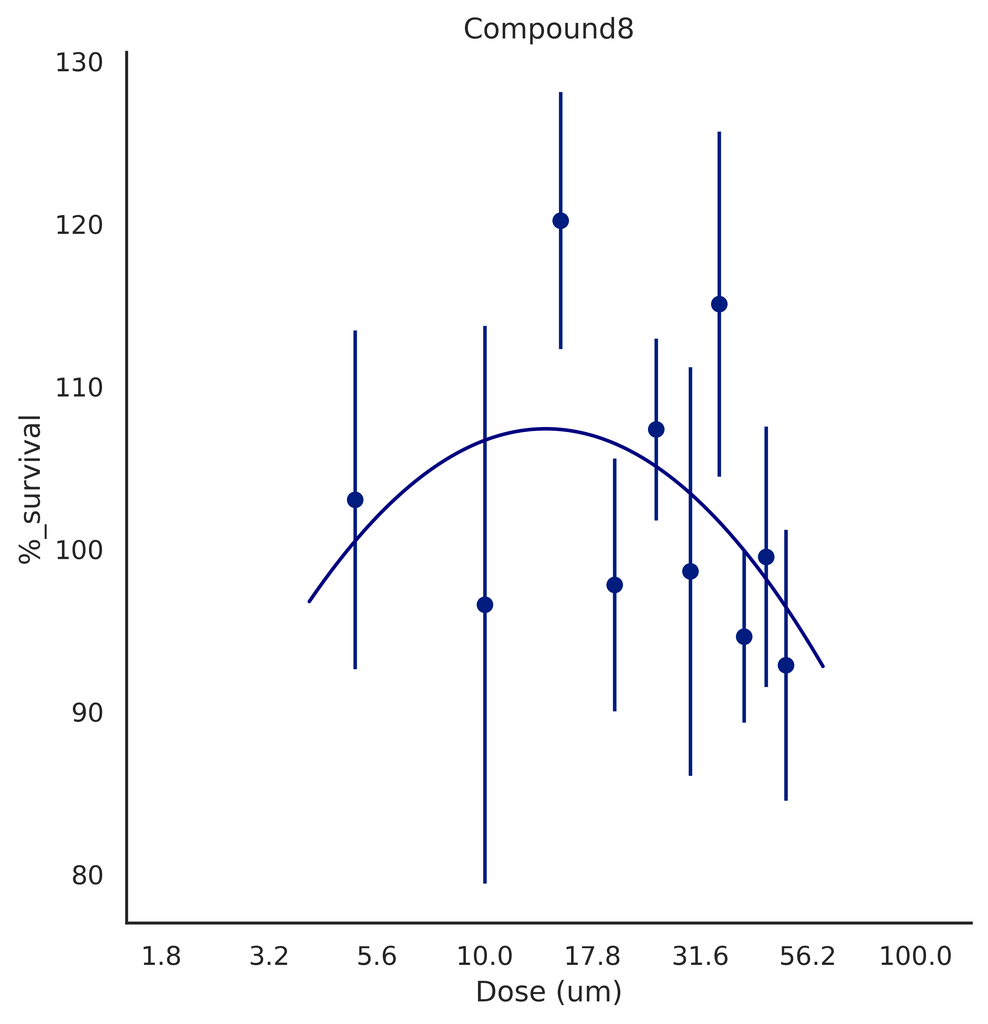

```python
Image(filename = path +'//polynomial_Compound8_failed.png',  width = 300)
```

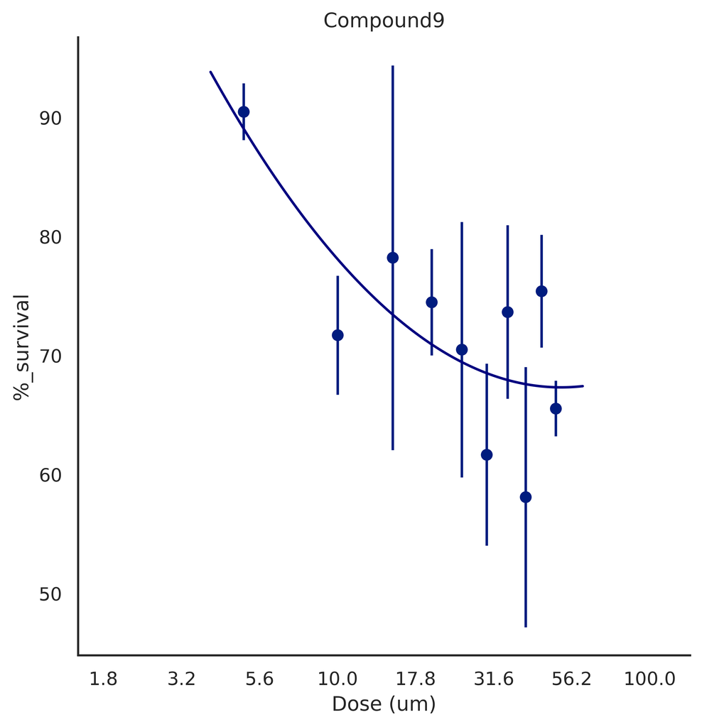

```python
Image(filename = path +'//polynomial_Compound9_failed.png',  width = 300)
```

#### Create ppt and html reports and clean output folder

```python
report = sd.create_presentation(path).save(path +'//xtt_report.pptx')
```

```python
# Create html report
! jupyter nbconvert --output-dir={path} --to html 05_xtt_assay.ipynb
```

```
[NbConvertApp] Converting notebook 05_xtt_assay.ipynb to html
[NbConvertApp] Writing 307302 bytes to xtt_output/05_xtt_assay.html
```

```python
# Clean pictures from output directory
for f in os.listdir(path):
    if '.png' in f:

        os.remove(path +'//' + f)
```